# Lecture 2, CSE 474/574

# Probability

**The vast majority of these notes are derived from [Castella and Berger](http://home.ustc.edu.cn/~zt001062/MaStmaterials/George%20Casella&Roger%20L.Berger--Statistical%20Inference.pdf), and from [Dr. Chandola's notebooks](https://mlcourse-ub.readthedocs.io/en/latest/docs.html).**

**You should also treat these as a compliment to the [Seeing Theory](https://seeing-theory.brown.edu/) suggested readings that we will also discuss in class.**

## Basic Definitions

- *Sample space* $S$: the set of all possible outcomes in an experiment
- *Event*: A collection of possible outcomes (a **set** of possible outcomes)
- *Sigma algebra* $\mathcal{B}$: essentially, all events that can be given a probability
- Axioms of probability:
1. $P(A) \geq 0$ for all $A \in \mathcal{B}$
2. $P(S) = 1$
3. If $A_1, A_2, ... \in \mathcal{B}$ are pairwise disjoint, then $P(\bigcup^{\infty}_{i=1} A_i) = \sum_{i=1}^\infty P(A_i)$

## Definition of a probability function

Assume there are a set of nonnegative numbers $p_1, ..., p_n$ that sum to one. If: $$P(A) = \sum_{\{i: s_i \in A\}} p_i$$

Then $P$ is a probability function (ignoring the stuff with $\mathcal{B}$, now)

### Example: Coin tossing

- $S = \{H, T\}$
- $\mathcal{B} : \{H\}, \{T\}$

**Exercise**: Prove that if $P(\{H\}) = P(\{T\})$, then $P(\{H\}) = P(\{T\}) = \frac{1}{2}$

## Conditional Probability

If $A$ and $B$ are events in $S$, and $P(B) \gt 0$, then the *conditional probability of A given B*, written as $P(A|B)$, is: $$P(A|B) = \frac{P(A \cap B)}{P(B)}$$ or equivalently, as $$P(A|B) = \frac{P(A = a, B =b)}{P(B=b)}$$ The latter notation will be useful below

**Exercise** Free sandwich to students. (Pg. 21-22)

Two variables are **statistically independent** if $P(A \cap B) = P(A)P(B)$. Naturally, if $P(A \cap B) \neq P(A)P(B)$, then the variables are *not* independent. **Machine learning is largely about leveraging these conditional relationships between variables.**

## Random Variables

A **random variable** is a function from a sample space $S$ into the real numbers.

**Exercise:** What is a random variable we could compute with:

- Two dice?
- One coin?
- A single session of a Facebook user?

**Exercise** Define the random variable $X$ to be the number of heads on 3 coin tosses.

1. Enumerate for each point in the sample space the value of $X$. (pg. 28)
2. Define $P_X(X=x)$ based on the induced probability function
3. What is $P_X(X=1)$?

### Distribution functions of a random variable

#### CDF

The *cumulative distribution function*, or *cdf*, of a random variable $X$ is defined as: $$F_X(x) = P_X(X\leq x),\mathrm{\, for\, all\,} x$$

**Exercise**: Draw the $cdf$ of $X$ when $X$ is the number of heads observed after tossing 3 fair coins.

#### PMF

The *probability mass function (pmf)* of a discrete random variable $X$ is given by: $$f_X(x) = P(X=x),\mathrm{\, for\, all\,} x$$

**Exercise**: Why is this only for discrete random variables?

Note: $$ P(X \leq b) = \sum_{k=1}^b f_X (k) = F_X(b)$$

#### PDF

The *probability density function (pdf)* of a continuous random variable $X$ is the function that satisfies: $$F_X(x) = \int_{-\infty}^x f_X(t) dt$$

### Continuous vs. Discrete

A random variable $X$ is **continuous** if $F_X(x)$ is a continuous function of $x$. It is *discrete* if $F_X(x)$ is a step function of $x$.

**Exercise**: What are some examples of continuous variables? Of discrete ones?

### Identically distributed RVs

Two random variables $X$ and $Y$ are *identically distributed* if $F_X(x) = F_Y(x)$ for all $x$

**Exercise** Define two identically distributed random variables that can be computed from a single coin tossed three times.

## Expected Value of a (Function of a) Random Variable

First, a note for this section: *If $X$ is a RV, then any function of $X$, say $g(x)$, is also a random variable*. For generality, we're going to use $g(X)$ instead of just $X$ here.

**The expected value, or expectation, of a random variable is simply the variable's average value, weighted by the probability of that value occurring**.

**Exercise**: What is the expected value of the random variable $X$, the number of heads I get when I flip a coin 100 times?

Formally, if $X$ is continuous, then:

$$ \mathbb{E} g(x) = \int_{-\infty}^{\infty} g(x) f_X(x) dx$$

And if $X$ is discrete, then:

$$ \mathbb{E} g(x) = \sum_{x \in \mathcal{X}} g(x)P(X=x)$$

A useful properties of expectations is linearity: **if a, b are constants, then $ \mathbb{E}(aX + b) = a \mathbb{E}(X) + b$**

## Variance of a Random Variable

The **variance** of a random variable $X$ is defined as: $$ \mathrm{Var} = \mathbb{E}(X - \mathbb{E}(X))^2 $$.

The **standard deviation** is equal to $\sqrt{\mathrm{Var}(X)}$.

Both of these measures give you an idea of the **spread** of the distribution. That is, the larger the variance, the larger the ... variability ... in $X$.

**Exercise** What does it mean if $\mathrm{Var}(X) = 0$?

## Probability distributions for univariate models (One random variable)

A **distribution** is a simplified **model** of a **population**. Because it is useful to have the same model be able to study different populations, statistical distributions are **families**, rather than a single pre-specified form. A specific instantiation of that family is determined by the value of the **parameter(s)** for that distribution.

```python
from scipy.stats import bernoulli, poisson, binom, norm, mvn, hypergeom
import numpy as np
from matplotlib import pyplot as plt
import matplotlib
import pandas as pd

import plotly.express as px
```

```python
headimg = plt.imread('data/quarterheads.jpg')
tailimg = plt.imread('data/quartertails.jpg')
```

### Probability distributions for discrete random variables

A random variable is generated from a probability distribution. There are different types of distributions defined for discrete random variables. These include:

- Bernoulli distribution
- Binomial distribution
- Multinoulli distribution
- Poisson distribution

#### Bernoulli distribution

Bernoulli distribution represents a binary random variable which takes value 1 with success probability $p$ and value 0 with failure probability $q=1-p$. A bernoulli distribution has only one parameter: $p$.

```
[0]
```

[figure not shown]

```python
theta = 0.5
# let us draw a sample from a bernoulli distribution
b = bernoulli.rvs(theta,size=1)
print(b)
if b[0] == 0:
    plt.imshow(tailimg)
    plt.axis('off')
else:
    plt.imshow(headimg)
    plt.axis('off')
```

```python
# you can also draw samples simultaneously
theta = 0.9
samples = bernoulli.rvs(theta,size=1000)
print(samples)
# count the number of successes (sample = 1). What happens when you change p?
print(np.count_nonzero(samples==1))
```

```
[1 1 1 1 1 1 1 0 1 1 1 1 1 1 1 1 1 1 1 1 1 1 1 1 1 1 1 0 1 1 0 0 1 1 1 1 1
 1 1 1 1 1 1 1 1 1 1 1 1 1 1 1 0 1 1 1 1 1 1 0 1 1 1 1 1 1 1 1 1 0 1 0 1 1
 1 1 0 1 1 1 1 1 1 1 1 1 1 1 1 1 1 0 1 1 1 1 0 0 1 1 1 1 0 1 1 0 1 1 1 1 1
 1 1 1 1 1 1 1 1 1 1 1 1 1 1 1 0 1 1 1 1 1 0 1 1 1 1 1 1 1 1 1 1 1 1 1 1 1
 1 1 1 1 1 1 1 1 1 1 1 1 1 1 1 1 1 0 1 0 1 0 1 1 1 1 1 1 1 1 1 0 1 1 1 0 1
 1 1 1 1 1 1 1 1 1 1 1 0 1 0 1 1 1 1 1 1 0 1 1 1 1 1 1 1 1 1 1 1 1 1 1 1 1
 0 0 1 1 1 1 1 1 1 1 1 0 1 1 1 1 0 1 1 1 1 1 1 1 0 1 1 1 1 1 1 1 0 1 0 0 1
 1 0 1 0 1 0 1 1 1 1 1 0 1 1 1 1 1 0 1 1 1 1 1 1 1 1 1 1 1 1 1 1 1 1 1 1 1
 1 1 1 1 1 1 1 1 0 1 1 1 1 1 1 1 1 1 1 1 1 1 1 1 1 1 1 1 1 1 1 1 1 1 0 0 1
 1 1 1 1 1 1 1 1 1 1 1 1 1 1 1 1 1 1 1 1 1 1 1 1 1 1 1 1 1 1 1 1 1 1 1 1 1
 1 1 1 1 1 0 1 1 1 1 1 1 1 1 1 1 1 1 1 1 0 1 1 1 1 1 1 0 1 1 1 1 0 1 1 0 1
 1 1 1 1 1 1 1 1 0 1 1 1 1 1 1 0 1 1 1 1 1 1 1 1 1 1 1 1 1 1 1 0 1 0 1 1 1
 1 1 1 0 1 1 1 1 1 1 0 0 1 1 1 1 1 1 1 1 1 1 1 1 1 1 1 1 0 1 1 1 1 1 1 1 1
 1 1 1 1 0 1 1 1 1 1 1 1 1 1 1 1 1 0 1 1 1 0 1 1 0 1 1 1 1 1 1 1 1 1 1 1 1
 0 0 1 1 1 1 1 1 1 1 0 1 1 1 1 1 1 1 1 0 1 1 1 1 1 1 1 0 1 1 1 0 1 1 1 1 0
 1 1 1 0 1 1 1 1 1 1 1 1 1 1 1 1 1 1 1 1 1 1 1 1 1 1 1 1 0 1 1 1 0 1 1 1 1
 1 0 1 1 1 1 1 1 1 1 1 1 0 1 1 0 1 1 1 1 1 1 1 1 1 1 1 1 1 1 1 1 1 1 0 1 0
 1 1 1 1 1 1 1 1 1 1 1 1 1 1 1 1 1 1 1 1 1 1 1 1 1 1 1 1 1 1 0 1 1 1 0 1 1
 0 1 0 1 1 0 1 1 1 1 1 1 1 1 1 1 1 1 1 1 1 1 0 1 0 1 1 1 1 1 1 1 1 1 1 1 1
 1 1 1 1 1 1 1 1 1 1 1 1 1 1 1 1 0 1 1 1 0 1 1 1 1 1 1 1 1 1 1 1 1 1 1 1 1
 1 1 1 1 1 1 1 1 1 1 1 1 1 1 1 0 1 1 1 1 1 1 1 1 1 1 1 1 1 1 1 1 1 1 1 1 1
 0 1 1 1 1 1 1 1 1 1 0 0 1 1 1 1 1 1 0 1 1 1 1 1 1 0 1 1 1 1 1 1 1 1 1 1 1
 1 1 1 1 1 1 1 1 1 1 1 1 1 1 1 0 1 1 1 1 1 1 1 1 1 0 1 1 0 1 1 1 1 1 1 1 1
 0 1 1 1 1 1 1 1 1 1 1 1 0 1 1 1 1 1 0 1 1 1 1 1 1 1 0 1 1 1 1 1 1 1 0 1 1
 1 1 1 1 1 1 1 1 0 1 0 1 1 1 1 1 1 1 1 1 1 1 1 1 1 1 1 1 0 1 1 1 1 0 1 1 0
 1 1 1 1 1 1 1 1 1 1 1 0 1 1 0 0 1 1 1 1 1 1 1 1 1 1 1 1 1 0 1 1 1 1 1 1 1
 0 1 1 1 1 1 1 1 1 1 1 1 1 1 1 0 1 1 1 0 1 1 1 1 1 1 1 1 1 1 0 0 1 0 0 1 1
 1]
889
```

```python
bernoulli.pmf(a, theta)
```

[output not shown]

```python
# plotting the probability mass function for the Bernoulli distribution
a = np.arange(2) # domain of the bernoulli variable
THETAS = [0.1,0.2,0.6,0.8] # different parameters

df = pd.DataFrame([bernoulli.pmf(a, theta) for theta in THETAS], columns=['tails','heads'])
df = df.assign(theta=THETAS)
melted_df = pd.melt(df, id_vars="theta")
melted_df
```

|  | theta | variable | value |
| --- | --- | --- | --- |
| 0 | 0.1 | tails | 0.9 |
| 1 | 0.2 | tails | 0.8 |
| 2 | 0.6 | tails | 0.4 |
| 3 | 0.8 | tails | 0.2 |
| 4 | 0.1 | heads | 0.1 |
| 5 | 0.2 | heads | 0.2 |
| 6 | 0.6 | heads | 0.6 |
| 7 | 0.8 | heads | 0.8 |

```python
fig = px.bar(melted_df, x="variable", y="value",
             color="theta",
             facet_col="theta",
             title = "Bernoulli Probability",
             labels = {"variable" : "Heads or Tails<br>(0 or 1)",
                       "value" : "Probability"},
            height=400,
            width=800)
fig.show()
```

[interactive chart not shown]

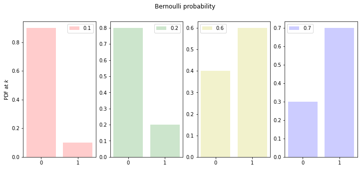

```python
colors = ['r','g','y','b']
plt.figure(figsize=(12,5))
for i, theta in enumerate([0.1, 0.2, 0.6, 0.7]):
    ax = plt.subplot(1, 4, i+1)
    plt.bar(a, bernoulli.pmf(a, theta), label=theta, color=colors[i], alpha=0.2)
    ax.xaxis.set_ticks(a)

    plt.legend(loc=0)
    if i == 0:
        plt.ylabel("PDF at $k$")


plt.suptitle("Bernoulli probability")
```

#### Binomial distribution

Another popular distribution for a discrete random variable is the **binomial distribution**. A binomial distribution has two parameters $n$ and $\theta$, where $0 \le \theta \le 1$. The sample generated by a binomial distribution denotes the number of successes observed in a sequence of $n$ binary trials (e.g., toss of a coin) when the probability of each success is $\theta$.

The samples that are drawn from a binomial distribution range between 0 and $n$.

The probability distribution is defined as: \begin{equation} p(k;n,\theta) = P(X = k) = \binom{n}{k}\theta^k (1 - \theta)^{n-k} \end{equation}

```python
#sampling from a binomial distribution
sample = binom.rvs(20,0.9,1)
print(sample)
```

```
17
```

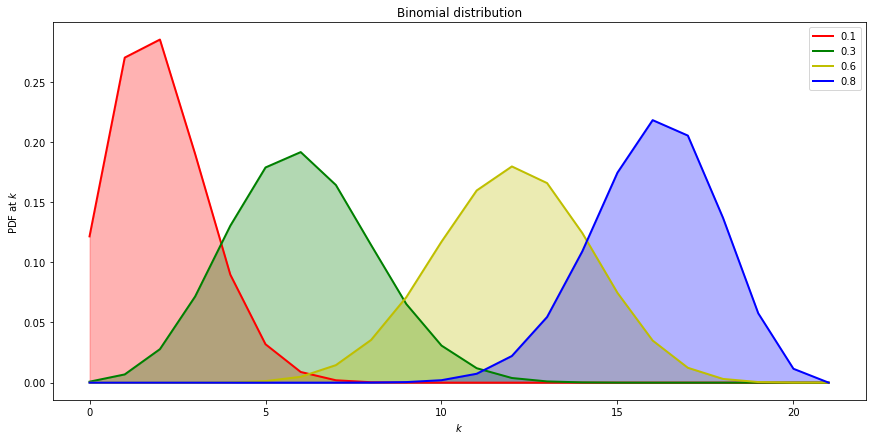

```python
#plotting the pmf for a bernoulli distribution
plt.figure(figsize=(12,6))
k = np.arange(0, 22)
for p, color in zip([0.1, 0.3, 0.6, 0.8], colors):
    rv = binom(20, p)
    plt.plot(k, rv.pmf(k), lw=2, color=color, label=p)
    plt.fill_between(k, rv.pmf(k), color=color, alpha=0.3)
plt.legend()
plt.title("Binomial distribution")
plt.tight_layout()
plt.ylabel("PDF at $k$")
plt.xlabel("$k$")
```

#### Poisson distribution

Typically used to model counts. Domain ($\chi$) is $0 ... \infty$. It has one parameter, $\lambda$.

The *probability mass function* is given as: $P(X = k) = \frac{\lambda^ke^{-\lambda}}{k!}$.

The expected value or mean of $X$ is $\lambda$.

```python
all_dfs = []
for lambd in [10, 25,50, 100]:
    rv = poisson(lambd)
    # calculate the pmf for different values of k and plot
    k = np.arange(200)
    all_dfs.append(pd.DataFrame(zip(k, rv.pmf(k), [lambd]*len(k)),
                                columns=['count','probability','lambda'])
                  )

df = pd.concat(all_dfs)

fig = px.bar(df, x="count",y="probability",facet_col='lambda',
                    facet_col_wrap=2,
             height=600, width=800)
fig.for_each_annotation(lambda a: a.update(text=a.text.split("=")[-1]))
fig.show()
```

[interactive chart not shown]

You see that the Poisson is a bit weird, the variance and the mean are encoded in a single parameter! The **negative binomial distribution** is very similar (with almost the same generative story), except that it allows for a difference between the values of the mean and variance of the distribution.

```
(0.0, 100.0)
```

[figure not shown]

```python
# generating samples from this distribution
samples = rv.rvs(1000)
h = plt.hist(samples,bins=20,density=True)
plt.xlim([0,100])
```

# Hypergeometric

```python
[M, n, N] = [52, 4, 5]
rv = hypergeom(M, n, N)
x = np.arange(0, n+1)
pmf_aces = rv.pmf(x)
[f'Prob of {i} aces: {j:.5f}'.format(i,j) for i,j in enumerate(pmf_aces)]
```

```
['Prob of 0 aces: 0.65884',
 'Prob of 1 aces: 0.29947',
 'Prob of 2 aces: 0.03993',
 'Prob of 3 aces: 0.00174',
 'Prob of 4 aces: 0.00002']
```

### Continuous random variables

A *continuous random* variable can take an infinite number of possible values. Several interesting distributions exist:

- alpha An alpha continuous random variable.
- beta A beta continuous random variable.
- gamma A gamma continuous random variable.
- expon An exponential continuous random variable.
- gauss Gaussian random variable

#### Gaussian distribution

One of the most popular distribution is the Gaussian distribution. This distribution is defined for any number of variables. For a single variable case, the distribution is defined using two parameters: $\mu$ and $\sigma$. $\mu$ or the **mean** can take any value and $\sigma$ or the **standard deviation** is $\ge 0$.

For a continuous distribution, you cannot compute the probability mass at any value of the random variable. Instead, you can compute the *density* using the **probability density function**: $$p(x) = \frac{1}{\sigma\sqrt{2\pi}}\exp[-\frac{1}{2}(\frac{x - \mu}{\sigma})^2]$$ The random variable represented using a Gaussian distribution can take any value from $-\infty$ to $\infty$.

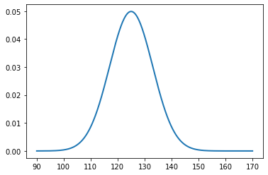

```python
# set the parameters
mu = 125
sigma = 8
# draw 1000 samples from this distribution
#samples = norm(mu, sigma).rvs(1000)
# plot an empirical distribution, i.e., a histogram
#h = plt.hist(samples, 30, density=True, alpha=.3)

# Compute the density at several instances of the random variable
x = np.linspace(90, 170, 10001)
# plot the density
plt.plot(x, norm(mu, sigma).pdf(x), linewidth=2)
```

#### Real-world example

Consider heights and weights of a population sample

```python
hw = pd.read_csv('data/heightweight.csv')
```

```python
fig = px.histogram(hw, x="Weight")
fig.show()
```

[interactive chart not shown]

## Multiple Random Variables (Multivariate models)

A fundamental component of multivariate statistics is a *n-dimensional random vector*, which is just a vector of random variables. It maps from a sample space $S$ into $\mathcal{R}^n$.

Let's simplify this, though, and just assume we have two random variables, $X$ and $Y$.

For a super neat visualization of conditional probability tables, [check out the first section of this website](http://colah.github.io/posts/2015-09-Visual-Information/).

### Joint PMF

The **joint probability mass function (joint pmf)** if $X$ and $Y$ are discrete is defined as $f(x,y) = P(X=x,Y=y)$. This **completely defines** the probability vectorof the random vector $(X,Y)$.

### Joint PDF

A function $f(x,y)$ is called a **joint probability density function (joint pdf)** if $X$ and $Y$ are continuous and for every $A \subset \mathcal{R}^2$:

$$P((X,Y) \in A) = \int_A \int f(x,y)dxdy$$

### Expectations of multiple random variables

Expectations of (functions of) two random variables are computed in the same ways as for single random variables.

In the discrete case: $$\mathbb{E}g(X,Y) = \sum_{(x,y)\in \mathcal{R}^2} g(x,y) f(x,y)$$.

### The marginal distribution

Again, assume that we are working only with the random vector $(X, Y)$. The *marginal distribution* of $X$ in this case is given as:

$$f_X(x) = \sum_{y \in \mathcal{R}} f_{X,Y}(x,y)$$

You **marginalize over** all values of $Y$, and then get a (well-specified) probability distribution over $X$.

Note the above is for the discrete case, the same follows in the expected fashion for multiple continous random variables.

### Conditional distributions

The *conditional probability* $P(X|Y)$ is (like we saw above): $P(Y=y | X=x) = \frac{P(X=x, Y=y)}{P(X=x)}$.

The **conditional distribution** of $(X,Y)$ follows similarly:

$$f(y|x) = P(Y=y|X=x) = \frac{f(x,y)}{f_X(x)}$$

### Independence of variables

Two variables are **independent** if for all $x \in \mathcal{R}$ and $y in \mathcal{R}$, $f(x,y) = f_X(x) f_Y(y)$. You can compute the probability of the two observations independently, and then just multiply them together!

### Covariance and Correlation

When random variables are *not* independent, we want to know the **strength** of the relationship between them. One measure of that is the **covariance**, defined as:

$$\mathrm{Cov}(X,Y) = \mathbb{E}((X-\mu_X)(Y-\mu_Y))$$

where $\mu_X = \mathbb{E}(X)$ and $\mu_Y = \mathbb{E}(Y)$.

The **correlation** between $X$ and $Y$ is defined by:

$$\rho_{XY} = \frac{\mathrm{Cov}(X,Y)}{\sigma_X \sigma_Y} $$

where $\sigma_X = \sqrt{\mathrm{Var}(X)}$, and analogously for $Y$.

**Exercise**: What is an example of two quantities that you would expect to see $\rho_{XY} = 0$? What about $\rho_{XY} = .9$? What about $\rho_{XY}= -.9$.

**A reminder for later... correlation is not causation, yes, but also, [be careful even with correlation!](https://www.youtube.com/watch?v=DbJyPELmhJc&ab_channel=AutodeskResearch).**

### Some multivariate probability distributions

#### Multinoulli distribution

A multinoulli distribution is a generalization of Bernoulli distribution for trials which can take more than two possibilities ($k > 2$). The parameter for multinoulli distribution is a vector ${\bf \theta}$ which has $k$ entries. Each entry $\theta_i$ indicates the probability of observing the category $i$ in a single trial.

```python
[1/6.]*6
```

```python
# generate samples from a multinoulli distribution. Essentially simulated a single roll of dice. Note that the output is a vector of length $k = 6$
np.random.multinomial(1, [1/6.]*6, size=1)
```

#### Multinomial distribution

A multinomial distribution is a generalization of Binomial distribution for trials which can take more than two possibilities. The parameters for the multinomial distribution is a vector ${\bf \theta}$ and $n$.

```python
# generate samples from a multinomial distribution. Note that the output is a vector of length $k = 6$
np.random.multinomial(20, [1/6.]*6, size=1)
```

#### Multi-dimensional or multivariate Gaussian distribution

A distribution can be defined for multivariate random variables. One example is the multivariate Gaussian. In general, the random variable is a $D$ length vector ${\bf X}$. The two parameters of this distribution are a mean vector ${\bf \mu}$ and a covariance matrix $\Sigma$. The pdf at any value of ${\bf X}$ is given by: $$ \mathcal{N}({\bf X}| {\bf \mu,\Sigma}) \triangleq \frac{1}{(2\pi)^{D/2}|{\bf \Sigma}|^{D/2}}exp\left[-\frac{1}{2}{\bf (x-\mu)^\top\Sigma^{-1}(x-\mu)}\right] $$ Note that if $D = 1$, it reduces to a univariate Gaussian distribution.

```python
#define the parameters for D = 2
mu = np.array([10,10])
Sigma = np.array([[4,1.],[1.,1]])
rv = np.random.multivariate_normal(mu,Sigma)
#sample some points
s = np.random.multivariate_normal(mu,Sigma,1000)

fig = plt.figure()
plt.subplot(111)
plt.scatter(s[:,0],s[:,1])

# add a contour plot
smin = np.min(s,axis=0)
smax = np.max(s,axis=0)
t1=np.linspace(smin[0],smax[0],1000)
t2=np.linspace(smin[1],smax[1],1000)

# evaluate pdf at each of these mesh points
```

[output not shown]

```python
np.cov(s.transpose())
```